# R Notebook

1. Usa la base de datos “Nivel de bienestar.sav” y marque la correcta.

```r
library(haven)

bienestar = read_sav("Nivel de bienestar.sav")
```

1. Tiene 14 valores perdidos en la variable “ingresos” (F)

```r
library(Hmisc)

describe(bienestar$ingresos)
```

2. Tiene 36 valores perdidos en tota006C (V) NO HAY LA VARIABLE!

```r
#describe(bienestar$)
```

3. Tiene 6 categorías distintas la variable “educ”

```r
table(bienestar$educ)
```

4. La variable “sexo” tiene dos modas

```r
describe(bienestar)
```

```r
dim(bienestar)
```

```
[1] 397  17
```

2. Usa la base de datos “Nivel de bienestar.sav”, recodifica en una variable dicotómica la variable “ingresos”. Usa el valor de la media como punto de corte para tener los dos grupos y marque la correcta.

```r
describe(bienestar$ingresos)
```

```
bienestar$ingresos : Ingresos  Format:F1.0
       n  missing distinct     Info     Mean      Gmd      .05      .10      .25      .50
     385       12      381        1     8464     7653     1425     1779     3474     6003
     .75      .90      .95
    9174    17102    25749

lowest :  1001  1009  1043  1047  1051, highest: 38515 43136 63987 72078 75150
```

```r
bienestar$ingresos_cat = ifelse(bienestar$ingresos > 8464, 1, 0)
```

```r
table(bienestar$ingresos_cat)
```

```
  0   1
267 118
```

1. Una categoría tiene el 30.6% de la información y la otra el 69.4%.

```r
prop.table(table(bienestar$ingresos_cat))
```

```
        0         1
0.6935065 0.3064935
```

2. Una categoría tiene el 32.5% de la información y la otra el 68.5%.
3. Una categoría tiene el 28.5% de la información y la otra el 72.5%.
4. Una categoría tiene 367 datos y la otra 218.
5. Una categoría cuenta con 118 datos y la otra 306
3. Usa la base de datos “Sinadef2.xlsx”, juntas las hojas “ESSALUD y otros1” y “ESSALUD y otros2” y genera un nuevo conjunto de datos llamado “DATA_TOTAL” (PARTE 1). Marque la correcta.

```r
library(readxl)

parte1 = read_excel("Sinadef2.xlsx",
                    sheet = 1)
```

| ID | TIPO SEGURO | SEXO | EDAD | ESTADO CIVIL |
| --- | --- | --- | --- | --- |
| 2 | ESSALUD | FEMENINO | 66 | SOLTERO |
| 3 | ESSALUD | MASCULINO | 68 | SOLTERO |
| 4 | ESSALUD | MASCULINO | 48 | SOLTERO |
| 5 | ESSALUD | MASCULINO | 59 | SOLTERO |
| 6 | ESSALUD | FEMENINO | 68 | CASADO |
| 7 | ESSALUD | MASCULINO | 43 | SOLTERO |

| ID | NIVEL DE INSTRUCCION | DEPARTAMENTO DOMICILIO | TIPO LUGAR | DÍAS DE ATENCIÓN |
| --- | --- | --- | --- | --- |
| 2 | SECUNDARIA COMPLETA | JUNIN | EESS | 1 |
| 3 | SUPERIOR UNIV. COMP. | LA LIBERTAD | EESS | 23 |
| 4 | SECUNDARIA COMPLETA | SAN MARTIN | EESS | 53 |
| 5 | SIN REGISTRO | LA LIBERTAD | EESS | 7 |
| 6 | SIN REGISTRO | SAN MARTIN | EESS | 17 |
| 7 | SIN REGISTRO | PIURA | EESS | 12 |

1. La moda de la variable “tipo de seguro” es “privados”. (F)

```r
describe(DATA_TOTAL$`TIPO SEGURO`)
```

```
DATA_TOTAL$`TIPO SEGURO`
       n  missing distinct
     647        0        8

lowest : ESSALUD       OTROS         PRIVADOS      SANIDAD EP    SANIDAD FAP
highest: SANIDAD EP    SANIDAD FAP   SANIDAD NAVAL SANIDAD PNP   SIN REGISTRO

Value            ESSALUD         OTROS      PRIVADOS    SANIDAD EP   SANIDAD FAP SANIDAD NAVAL
Frequency            476            20            18             6             2             3
Proportion         0.736         0.031         0.028         0.009         0.003         0.005

Value        SANIDAD PNP  SIN REGISTRO
Frequency             18           104
Proportion         0.028         0.161
```

2. Los hombres tienen más seguros “privados” que las mujeres. (V)

```r
describe(hombres$`TIPO SEGURO`)
```

```
hombres$`TIPO SEGURO`
       n  missing distinct
     378        0        8

lowest : ESSALUD       OTROS         PRIVADOS      SANIDAD EP    SANIDAD FAP
highest: SANIDAD EP    SANIDAD FAP   SANIDAD NAVAL SANIDAD PNP   SIN REGISTRO

Value            ESSALUD         OTROS      PRIVADOS    SANIDAD EP   SANIDAD FAP SANIDAD NAVAL
Frequency            283            14            12             4             2             1
Proportion         0.749         0.037         0.032         0.011         0.005         0.003

Value        SANIDAD PNP  SIN REGISTRO
Frequency             13            49
Proportion         0.034         0.130
```

```r
describe(mujeres$`TIPO SEGURO`)
```

```
mujeres$`TIPO SEGURO`
       n  missing distinct
     269        0        7

lowest : ESSALUD       OTROS         PRIVADOS      SANIDAD EP    SANIDAD NAVAL
highest: PRIVADOS      SANIDAD EP    SANIDAD NAVAL SANIDAD PNP   SIN REGISTRO

Value            ESSALUD         OTROS      PRIVADOS    SANIDAD EP SANIDAD NAVAL   SANIDAD PNP
Frequency            193             6             6             2             2             5
Proportion         0.717         0.022         0.022         0.007         0.007         0.019

Value       SIN REGISTRO
Frequency             55
Proportion         0.204
```

3. La mediana de edad es 68.48.

```r
describe(DATA_TOTAL$EDAD)
```

```
DATA_TOTAL$EDAD
       n  missing distinct     Info     Mean      Gmd      .05      .10      .25      .50
     647        0       81        1    68.48     18.2       40       47       59       70
     .75      .90      .95
      80       88       91

lowest :   1   2   4   6  21, highest:  98  99 100 101 104
```

4. Todas las variables tienen, por lo menos, un dato perdido.
4. A partir del nuevo conjunto de datos creado como “DATA_TOTAL” de la base de datos “Sinadef2.xlsx”, completa sus casos con la hoja “SIS” y genera un nuevo conjunto de datos (PARTE 2). Marque la correcta.

```r
sis = read_excel("Sinadef2.xlsx",
                    sheet = 3)
```

|  | ID | TIPO SEGURO | SEXO | EDAD | ESTADO CIVIL | NIVEL DE INSTRUCCION | DEPARTAMENTO DOMICILIO | TIPO LUGAR | DÍAS DE ATENCIÓN |
| --- | --- | --- | --- | --- | --- | --- | --- | --- | --- |
| 1 | 2 | ESSALUD | FEMENINO | 66 | SOLTERO | SECUNDARIA COMPLETA | JUNIN | EESS | 1 |
| 2 | 3 | ESSALUD | MASCULINO | 68 | SOLTERO | SUPERIOR UNIV. COMP. | LA LIBERTAD | EESS | 23 |
| 3 | 4 | ESSALUD | MASCULINO | 48 | SOLTERO | SECUNDARIA COMPLETA | SAN MARTIN | EESS | 53 |
| 4 | 5 | ESSALUD | MASCULINO | 59 | SOLTERO | SIN REGISTRO | LA LIBERTAD | EESS | 7 |
| 5 | 6 | ESSALUD | FEMENINO | 68 | CASADO | SIN REGISTRO | SAN MARTIN | EESS | 17 |
| 6 | 7 | ESSALUD | MASCULINO | 43 | SOLTERO | SIN REGISTRO | PIURA | EESS | 12 |

| ID | TIPO SEGURO | SEXO | EDAD | ESTADO CIVIL | NIVEL DE INSTRUCCION | DEPARTAMENTO DOMICILIO | TIPO LUGAR | DÍAS DE ATENCIÓN |
| --- | --- | --- | --- | --- | --- | --- | --- | --- |
| 1 | SIS | FEMENINO | 78 | SOLTERO | PRIMARIA COMPLETA | JUNIN | DOMICILIO | 54 |
| 8 | SIS | FEMENINO | 71 | CASADO | PRIMARIA COMPLETA | JUNIN | DOMICILIO | 46 |
| 10 | SIS | MASCULINO | 40 | SOLTERO | SIN REGISTRO | CALLAO | EESS | 20 |
| 12 | SIS | MASCULINO | 28 | SOLTERO | SIN REGISTRO | PIURA | EESS | 46 |
| 13 | SIS | MASCULINO | 87 | SOLTERO | NINGUN NIVEL / ILETRADO | CAJAMARCA | DOMICILIO | 32 |
| 15 | SIS | FEMENINO | 92 | SOLTERO | NINGUN NIVEL / ILETRADO | LA LIBERTAD | DOMICILIO | 41 |

```r
Data_Total_2 = merge(DATA_TOTAL, sis, all= T)
```

1. Hay 1200 casos y 7 variables

```r
dim(Data_Total_2)
```

[output not shown]

2. Con md.pattern puedo confirmar que no hay valores perdidos

```
 /\     /\
{  `---'  }
{  O   O  }
==>  V <==  No need for mice. This data set is completely observed.
 \  \|/  /
  `-----'

     ID TIPO SEGURO SEXO EDAD ESTADO CIVIL NIVEL DE INSTRUCCION DEPARTAMENTO DOMICILIO TIPO LUGAR
1200  1           1    1    1            1                    1                      1          1
      0           0    0    0            0                    0                      0          0
     DÍAS DE ATENCIÓN
1200                1 0
                    0 0
```

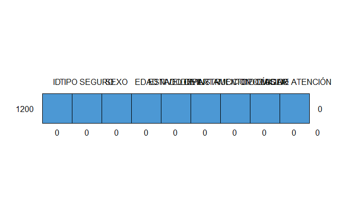

```r
library(mice)
md.pattern(Data_Total_2)
```

3. La variable “días de atención” tiene como media 34.

```r
describe(Data_Total_2$`DÍAS DE ATENCIÓN`)
```

```
Data_Total_2$`DÍAS DE ATENCIÓN`
       n  missing distinct     Info     Mean      Gmd      .05      .10      .25      .50
    1200        0       63        1    32.27    20.84        3        7       17       33
     .75      .90      .95
      47       57       61

lowest :  1  2  3  4  5, highest: 59 60 61 62 63
```

5. Usa la base de datos “Sinadef1.xlsx” y marque la correcta.
1. La mediana de la variable “días” de atención es 33.

```r
describe(sinadef1$`DÍAS DE ATENCIÓN`)
```

```
sinadef1$`DÍAS DE ATENCIÓN`
       n  missing distinct     Info     Mean      Gmd      .05      .10      .25      .50
    1200        0       63        1    32.27    20.84        3        7       17       33
     .75      .90      .95
      47       57       61

lowest :  1  2  3  4  5, highest: 59 60 61 62 63
```

2. El valor máximo de la variable “edad” es 101.

```r
describe(sinadef1$EDAD)
```

```
sinadef1$EDAD
       n  missing distinct     Info     Mean      Gmd      .05      .10      .25      .50
    1200        0       92        1    67.47     19.5       36       45       58       70
     .75      .90      .95
      80       88       92

lowest :   1   2   3   4   5, highest:  99 100 101 102 104
```

3. La media de la variable “edad” es 19.5

```r
describe(sinadef1$EDAD)
```

```
sinadef1$EDAD
       n  missing distinct     Info     Mean      Gmd      .05      .10      .25      .50
    1200        0       92        1    67.47     19.5       36       45       58       70
     .75      .90      .95
      80       88       92

lowest :   1   2   3   4   5, highest:  99 100 101 102 104
```

4. Hay una mayor cantidad de Femenino que Masculino en la variable “sexo”.

```r
describe(sinadef1$SEXO)
```

```
sinadef1$SEXO
       n  missing distinct
    1200        0        2

Value       FEMENINO MASCULINO
Frequency        526       674
Proportion     0.438     0.562
```

6. En la variable “edad” de la base de datos “Sinadef1.xlsx”, seleccionar los casos del 130 al 139 y del 870 al 879, e indicar el valor mínimo y máximo de este subconjunto. Marque la correcta.

```r
describe(sinadef1_sub$EDAD)
```

```
sinadef1_sub$EDAD
       n  missing distinct     Info     Mean      Gmd      .05      .10      .25      .50
      20        0       18    0.998    71.65    17.77    47.60    51.60    64.00    74.50
     .75      .90      .95
   79.50    91.20    93.25

lowest : 40 48 52 53 64, highest: 81 86 91 93 98

Value        40   48   52   53   64   66   67   68   74   75   77   78   79   81   86   91   93
Frequency     1    1    1    1    2    1    1    1    1    1    1    1    2    1    1    1    1
Proportion 0.05 0.05 0.05 0.05 0.10 0.05 0.05 0.05 0.05 0.05 0.05 0.05 0.10 0.05 0.05 0.05 0.05

Value        98
Frequency     1
Proportion 0.05
```

1. 64 y 81
2. 40 y 98
3. 41 y 98
7. Usa la base de datos “Sinadef1.xlsx” y marque la correcta.
1. La variable “Edad” cuenta con todos los casos completos.

```r
describe(sinadef1$EDAD)
```

```
sinadef1$EDAD
       n  missing distinct     Info     Mean      Gmd      .05      .10      .25      .50
    1200        0       92        1    67.47     19.5       36       45       58       70
     .75      .90      .95
      80       88       92

lowest :   1   2   3   4   5, highest:  99 100 101 102 104
```

2. La variable “Departamento” tiene 7 valores perdidos. (incorrecta)

```r
describe(sinadef1$`DEPARTAMENTO DOMICILIO`)
```

```
sinadef1$`DEPARTAMENTO DOMICILIO`
       n  missing distinct
    1200        0       27

lowest : AMAZONAS     ANCASH       APURIMAC     AREQUIPA     AYACUCHO
highest: SAN MARTIN   SIN REGISTRO TACNA        TUMBES       UCAYALI
```

3. El “estado civil” del caso 547 es soltero.

| TIPO SEGURO | SEXO | EDAD | ESTADO CIVIL | NIVEL DE INSTRUCCIÓN | DEPARTAMENTO DOMICILIO | TIPO LUGAR | DÍAS DE ATENCIÓN |
| --- | --- | --- | --- | --- | --- | --- | --- |
| ESSALUD | FEMENINO | 81 | SOLTERO | PRIMARIA COMPLETA | LA LIBERTAD | DOMICILIO | 8 |

4. La región Amazonas es la “región” con menos casos. (incorrecta)

```r
table(sinadef1$`DEPARTAMENTO DOMICILIO`)
```

```
     AMAZONAS        ANCASH      APURIMAC      AREQUIPA      AYACUCHO     CAJAMARCA        CALLAO
            3            41            24            75            13            38            41
        CUSCO    EXTRANJERO  HUANCAVELICA       HUANUCO           ICA         JUNIN   LA LIBERTAD
           44             2            15            22            60            73            80
   LAMBAYEQUE          LIMA        LORETO MADRE DE DIOS      MOQUEGUA         PASCO         PIURA
           34           443            11             1             5            13            75
         PUNO    SAN MARTIN  SIN REGISTRO         TACNA        TUMBES       UCAYALI
           36            29             3             4             6             9
```

Ctrl+Alt+i –> abre un chunk